# Exploração de dados Goiás

Aline Mendonça,Brisne Velasquez,Renata Santos

## Parte I - Importação de Dados

## Importação das abas do DataSet

## Selecionando os dados dos Municípios de Goías

## Criando um único banco de dados exclusivo dos municipios de Goiás

## Análise dos dados

## GOIÁS

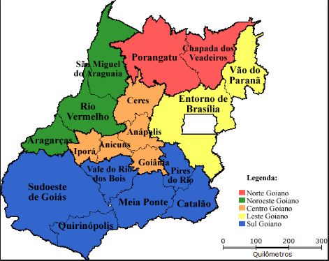

## População Goiânia

## Como é a distribuição por faixas da população dos municípios goiânios?

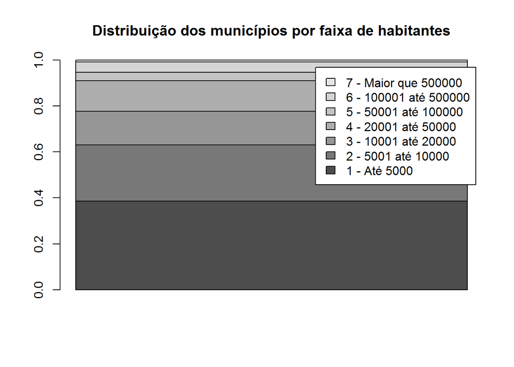

60% dos municípios goiânios possui até 10 mil habitantes.

## Quantos habitantes há nos municípios goianos desconsiderandos os outliars?

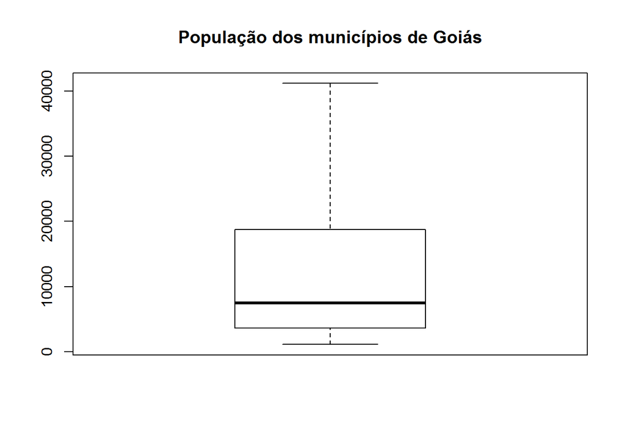

```
## [1] 52
```

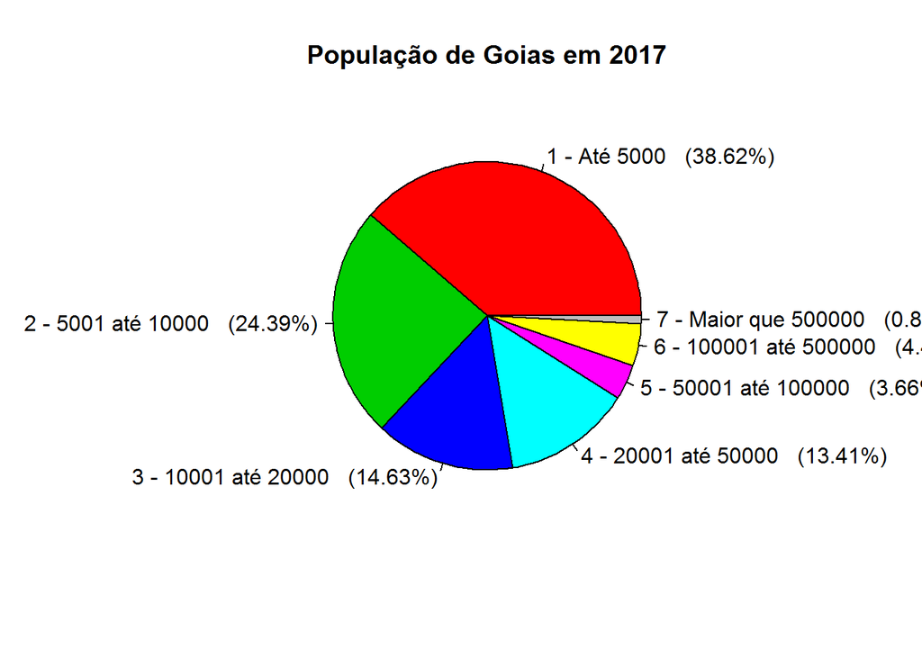

Goiás possui 6.778.772 habitantes, sendo 1.466.105 (21,63%) vivendo em Goiânia, a capital do Estado.

## Perfil dos Prefeitos dos Municípios de Goiás

## Qual é a Idade dos Prefeitos dos Municípios de Goiás?

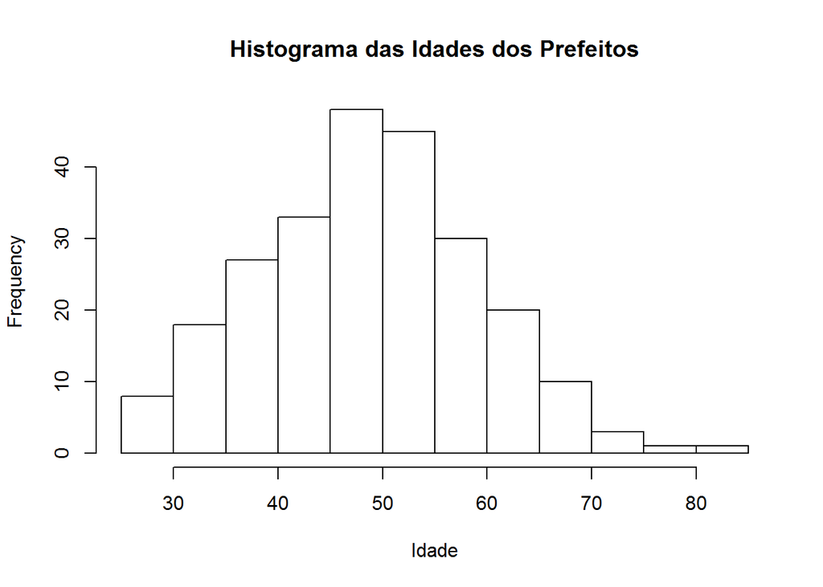

Mais de 50% possui entre 40 e 60 anos.

## Qual é a Idade dos Prefeitos dos Municípios de Goiás?

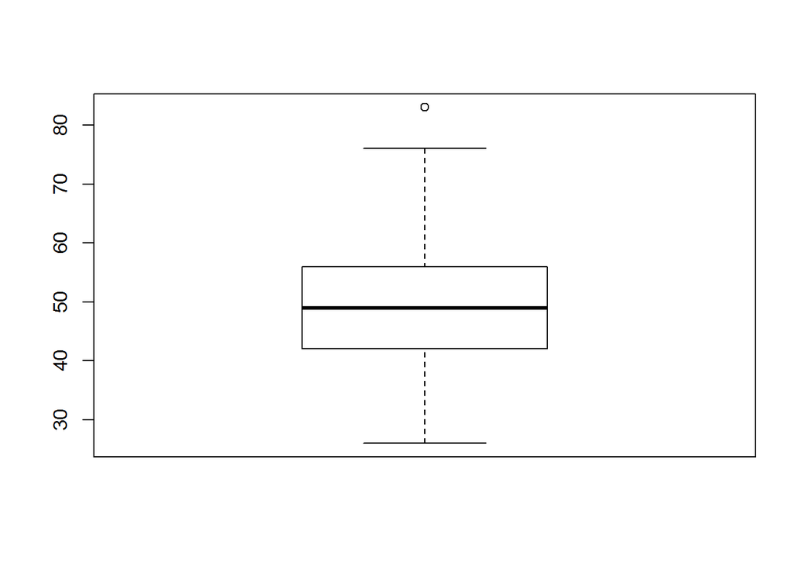

A idade média dos prefeitos é 50 anos.

## Qual é o percentual de prefeito eleito por partido?

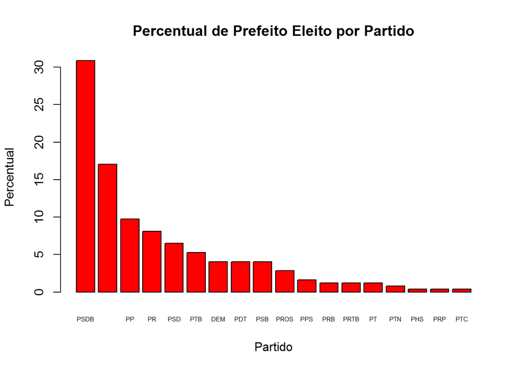

O PSDB e o PMDB elegeram quase 50% dos prefeitos de Goiás.

## Qual é o percentual de prefeitos re-eleitos?

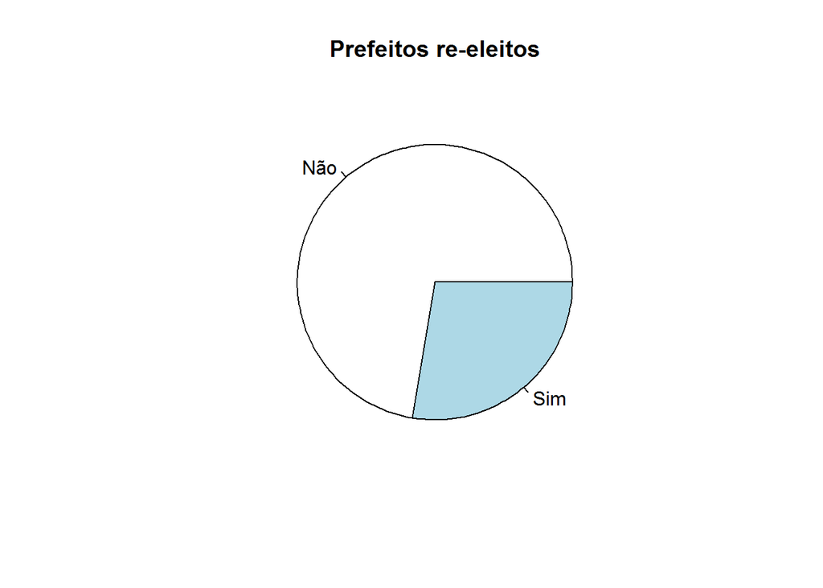

Aproximadamente 1/3 dos prefeitos foram re-eleitos.

## Qual é o percentual de prefeito re-eleito por partido?

```
##
##           Não    Sim
##   DEM   80.00  20.00
##   PDT   90.00  10.00
##   PHS    0.00 100.00
##   PMDB  76.19  23.81
##   PP    79.17  20.83
##   PPS   75.00  25.00
##   PR    80.00  20.00
##   PRB  100.00   0.00
##   PROS  57.14  42.86
##   PRP  100.00   0.00
##   PRTB 100.00   0.00
##   PSB   90.00  10.00
##   PSD   75.00  25.00
##   PSDB  59.21  40.79
##   PT    33.33  66.67
##   PTB   76.92  23.08
##   PTC  100.00   0.00
##   PTN  100.00   0.00
```

```
##
##          Não   Sim
##   DEM   4.49  2.94
##   PDT   5.06  1.47
##   PHS   0.00  1.47
##   PMDB 17.98 14.71
##   PP   10.67  7.35
##   PPS   1.69  1.47
##   PR    8.99  5.88
##   PRB   1.69  0.00
##   PROS  2.25  4.41
##   PRP   0.56  0.00
##   PRTB  1.69  0.00
##   PSB   5.06  1.47
##   PSD   6.74  5.88
##   PSDB 25.28 45.59
##   PT    0.56  2.94
##   PTB   5.62  4.41
##   PTC   0.56  0.00
##   PTN   1.12  0.00
```

## Qual é o nivel médio de escolaridade dos Prefeitos de Goiás?

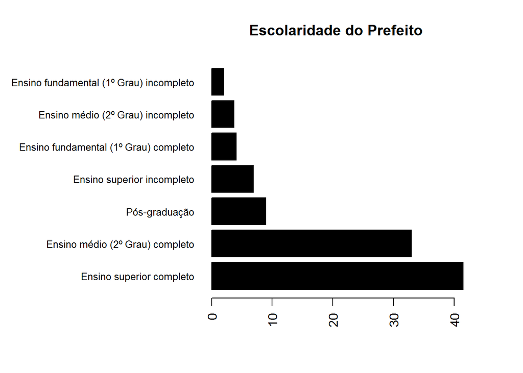

Mais de 40% dos prefeitos eleitos possuem Ensino Superior Completo.

## Qual é a distribuição do sexo dos prefeitos?

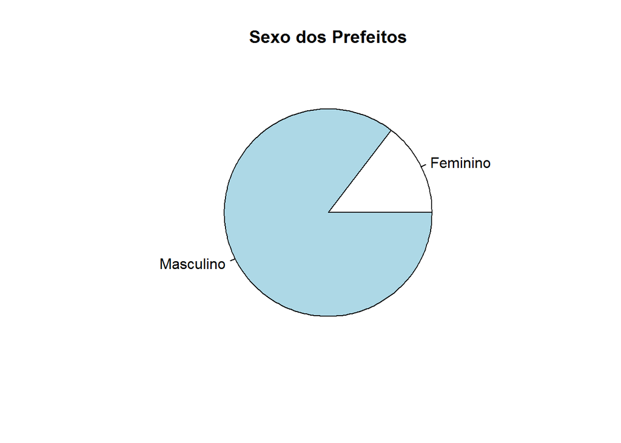

Apenas 15% dos prefeitos eleitos são do sexo feminino.

## Recursos humanos por vínculo

## Como é a composição do quadro de pessoal da administração direta dos três Municípios que percentualmente menos possuem funcionários estatutários em Goiás?

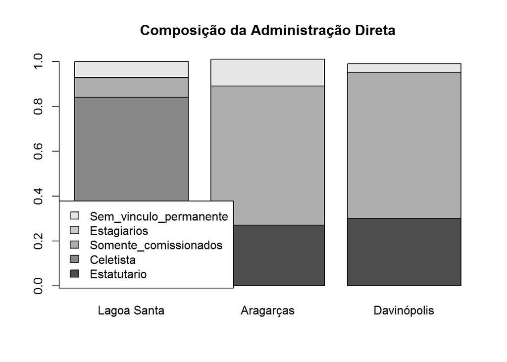

Lagoa Santa não possui funcionários estatutários atuando na Adminitração Direta. Aragarças e Davinópolis possuem aproximadamente 30% dos funcionários estatutários.

## Como é a composição do quadro de pessoal da administração direta do Estado de Goiás?

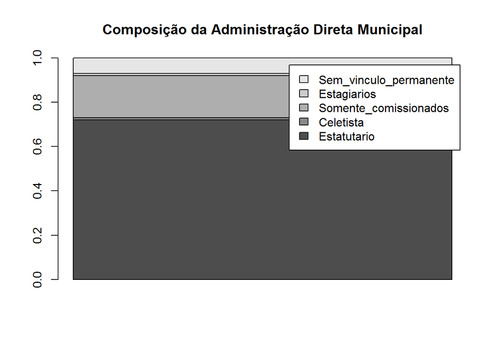

Aproximadamente 25% dos funcionários não é estatutário.

## Quantos funcinários Estatutários há na Administração Direta dos Municípios de Goiás?

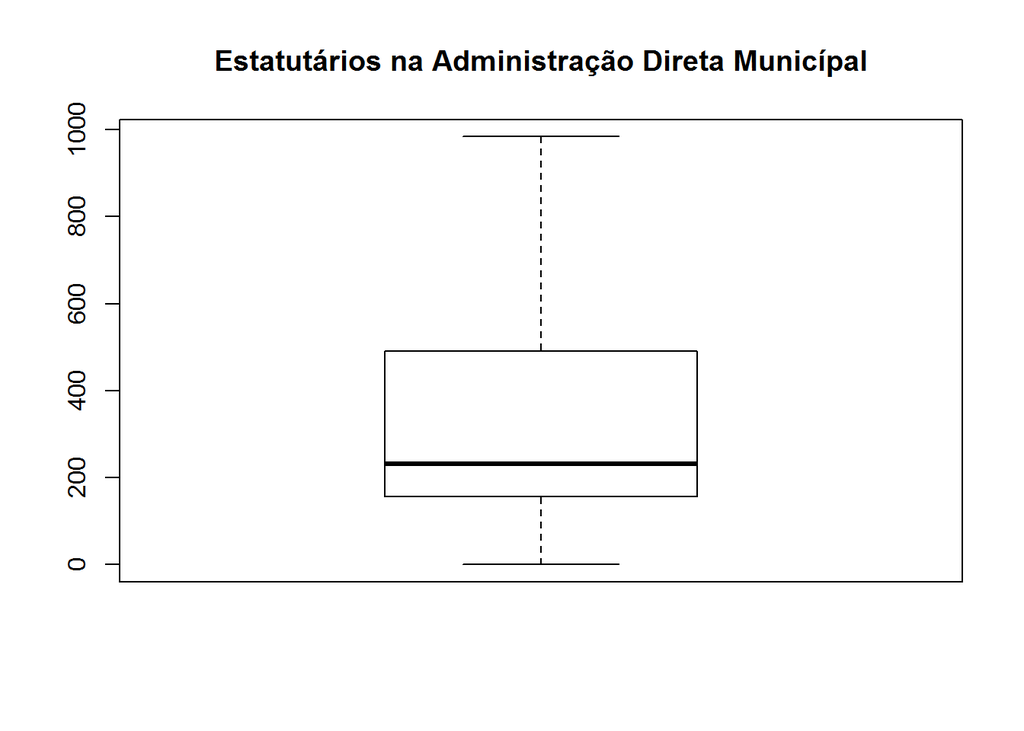

Há em média 200 estatutátios na administração direta municipal.

## Quantos funcinários Celetistas há na Administração Direta dos Municípios de Goiás?

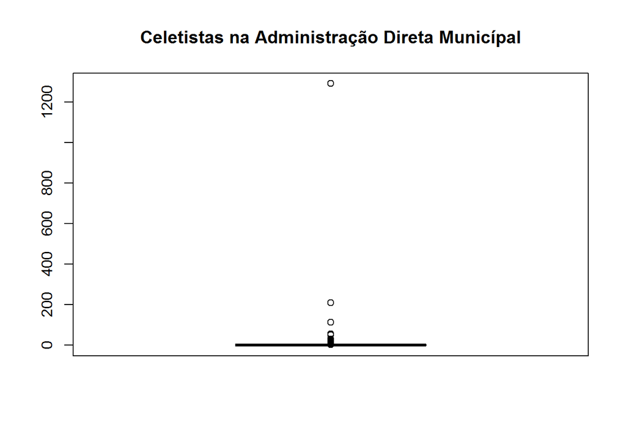

```
## [1] 21
```

```
## [1] 8.54
```

Em apenas 21 (8,5%) municípios há celetistas na administração direta municipal.

## Quantos funcinários Comissionados há na Administração Direta dos Municípios de Goiás?

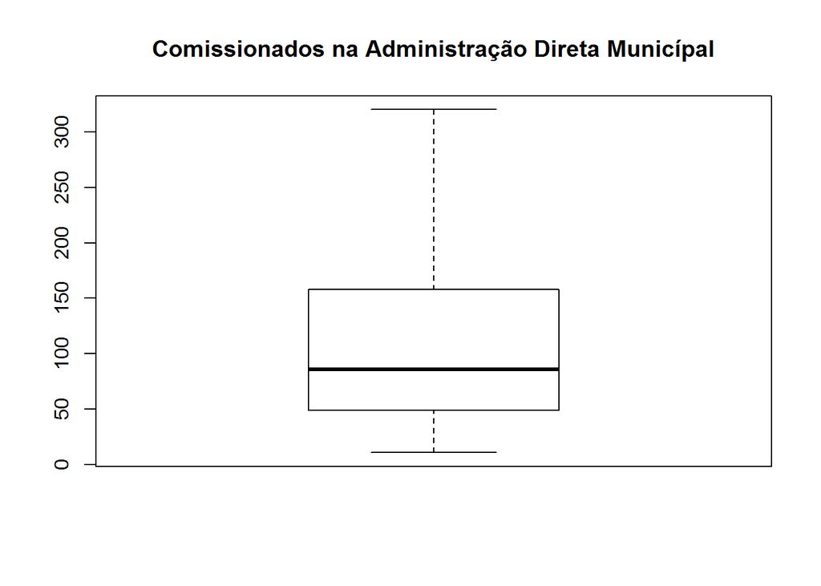

Há em média 75 comissionados na administração direta municipal.

## Quantos Estagiários há na Administração Direta dos Municípios de Goiás?

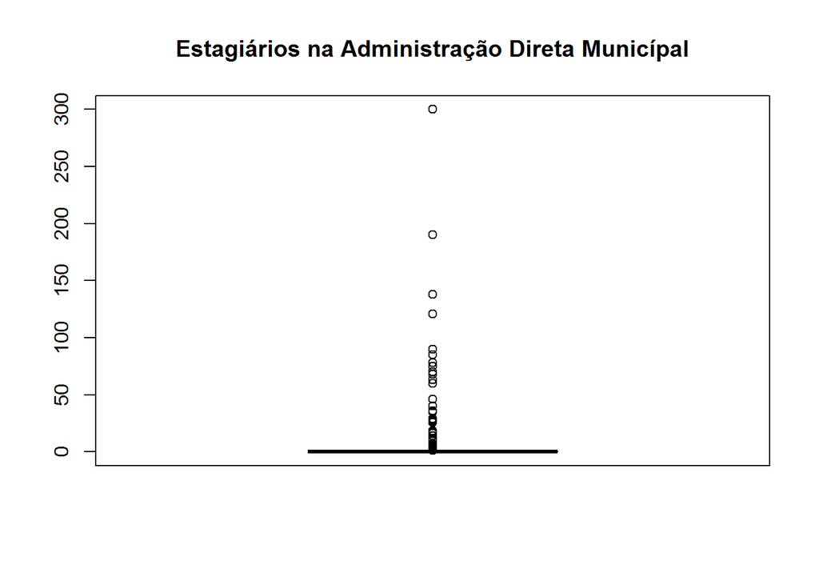

```
## [1] 52
```

```
## [1] 21.14
```

## Quantos funcionários sem vínculo permanente há na Administração Direta dos Municípios de Goiás?

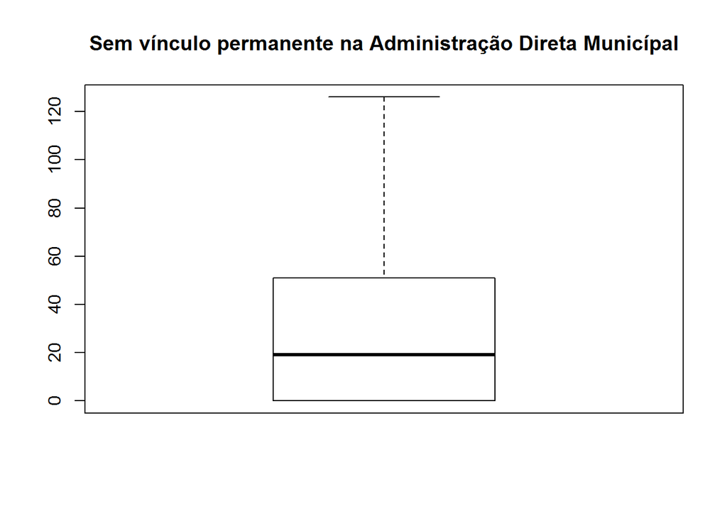

Há em média 20 funcionários sem vínculo permanente na Administração Direta Municipal.

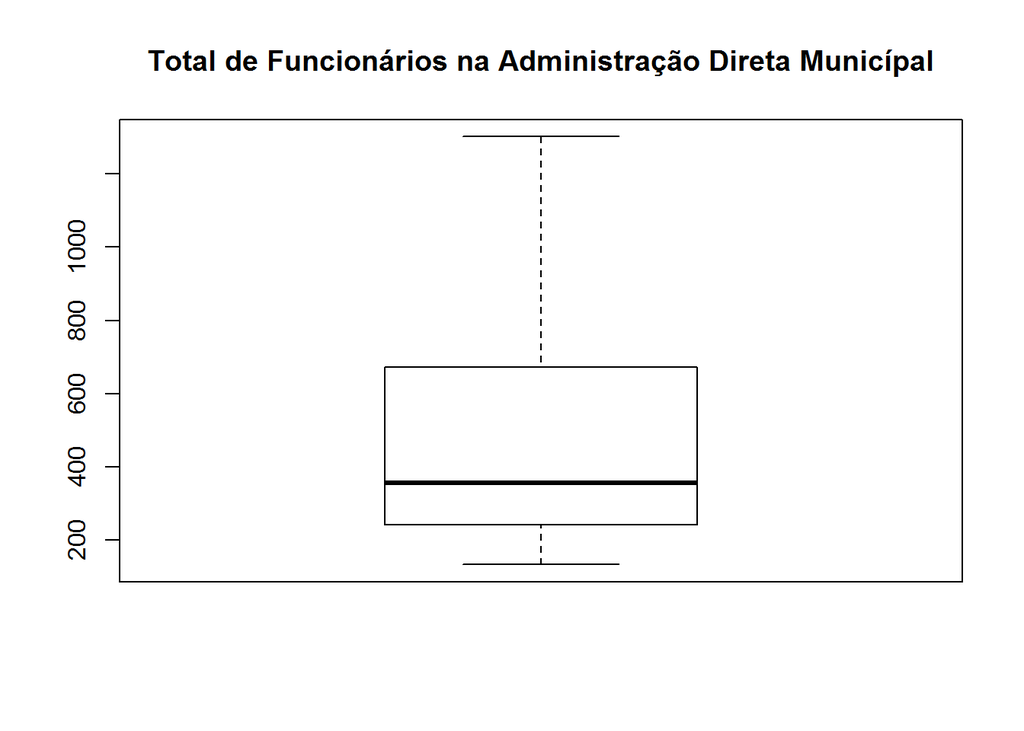

Há em média 350 funcionários ao todo na administração Direta Municipal.

## Percentual de Municípios que possuem quadro de pessoal da administração indireta

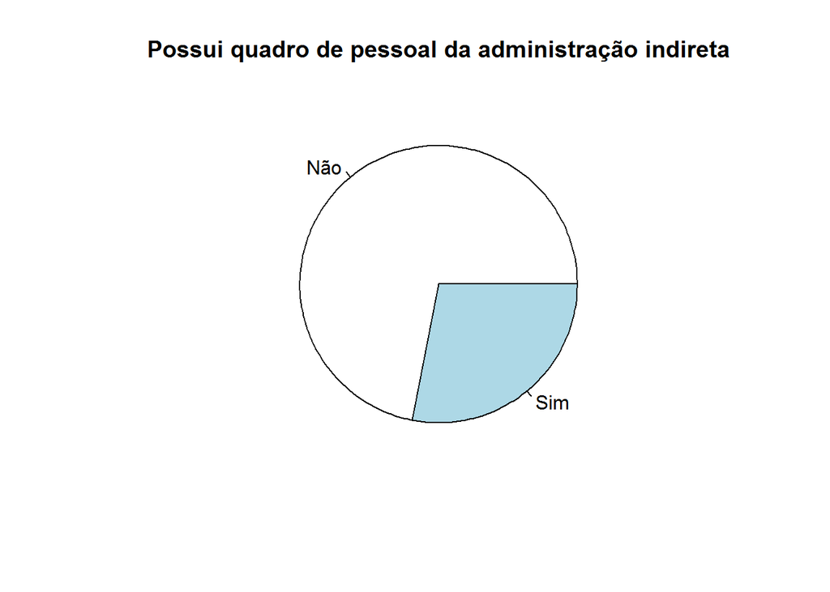

```
##
##       Não       Sim
## 0.7195122 0.2804878
```

28% dos municípios possuem administração indireta.

## Como é a composição do quadro de pessoal da administração indireta dos três Municípios que percentualmente menos possuem funcionários estatutários em Goíás?

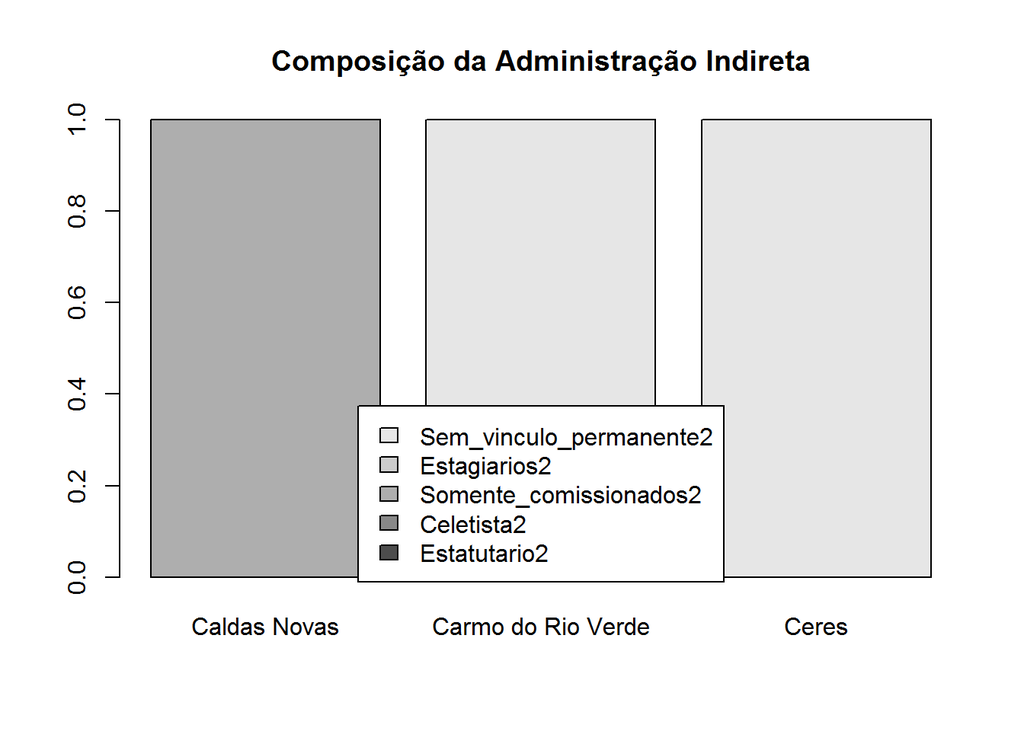

## Como é a composição do quadro de pessoal da administração indireta do Estado de Goiás?

```
## [1] 0.37 0.48 0.12 0.01 0.02
```

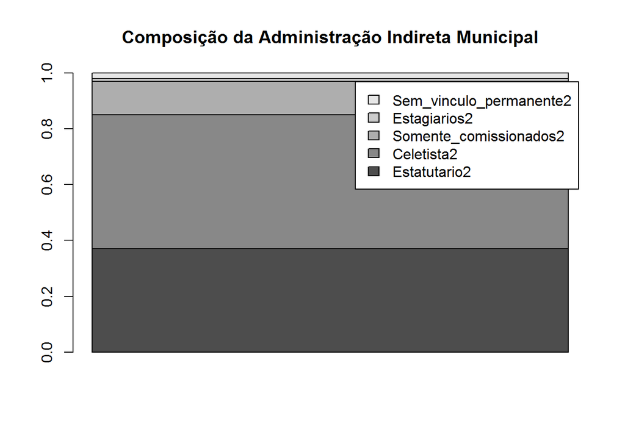

Aproximadamente 50% dos funcionários que atuam na administração indireta municipal são celetistas.

## Quantos funcinários Estatutários há na Administração Indireta dos Municípios de Goiás?

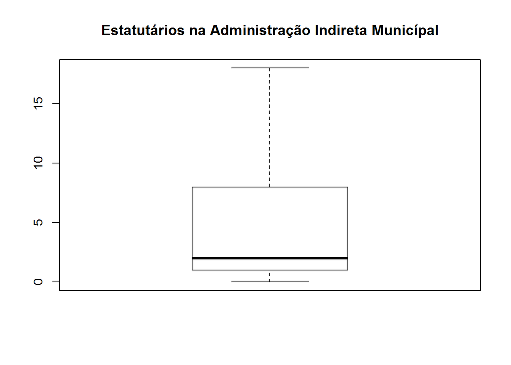

```
## [1] 56
```

```
## [1] 22.76
```

Há 56 (23%) municípios que possuem estatuários na Administração Indireta

## Quantos funcinários Celetistas há na Administração Indireta dos Municípios de Goiás?

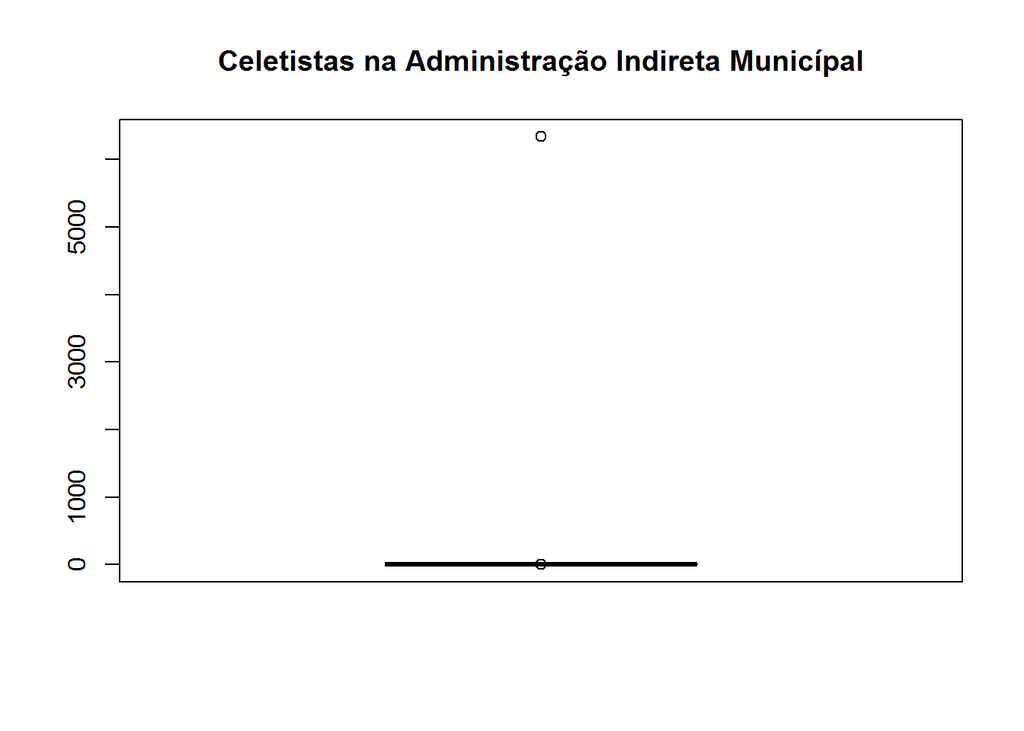

```
## [1] 2
```

```
## [1] 0.81
```

## Quantos funcinários Comissionados há na Administração Indireta dos Municípios de Goiás?

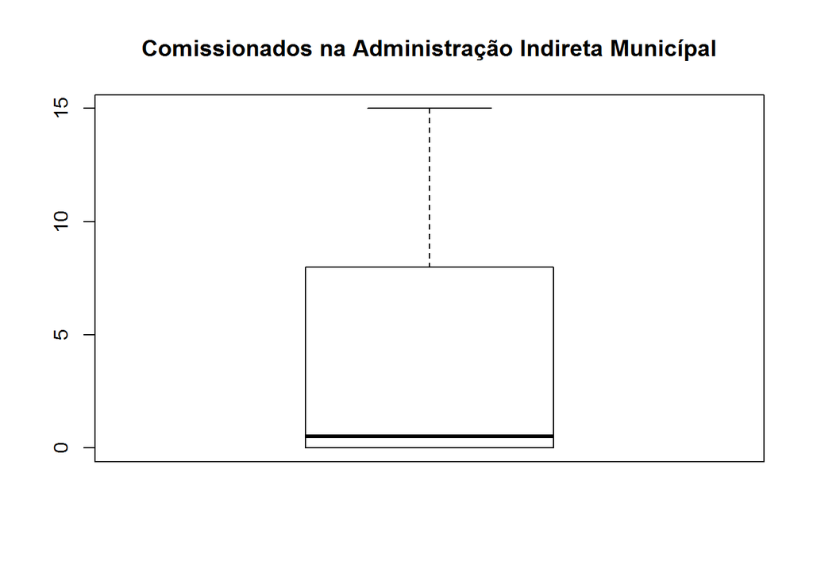

```
## [1] 34
```

```
## [1] 13.82
```

Há funcionários comissionados em 34(13,82%) municipios na administração indireta.

## Quantos estagiários há na Administração Indireta dos Municípios de Goiás?

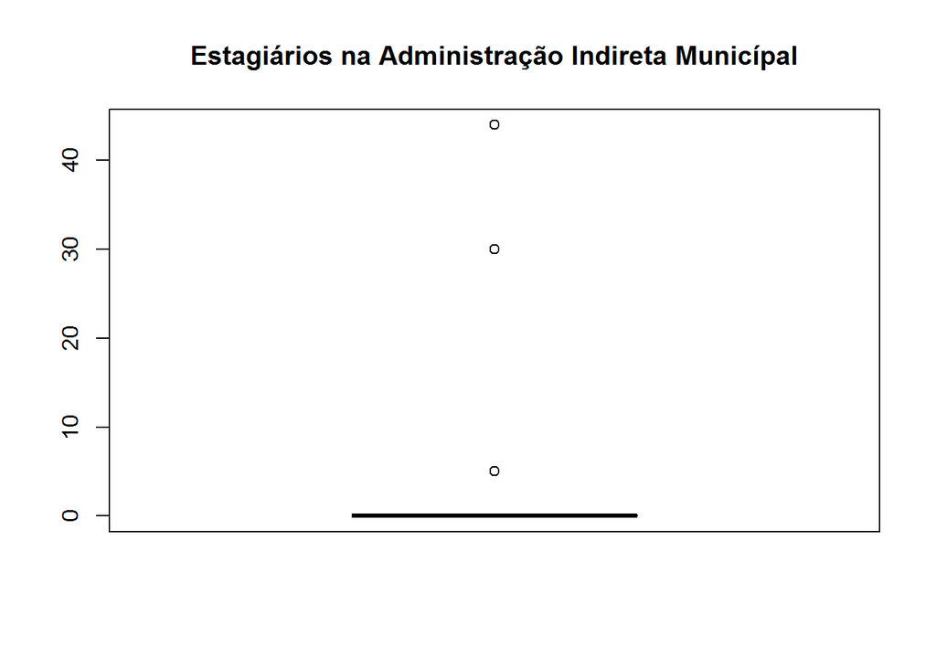

```
## [1] 3
```

```
## [1] 1.22
```

## Quantos funcionários sem vínculo permanente há na Administração Indireta dos Municípios de Goiás?

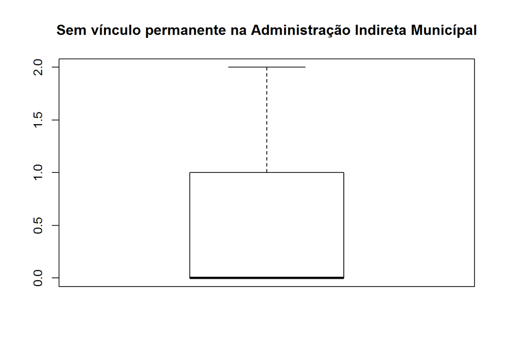

```
## [1] 23
```

```
## [1] 9.35
```

Há funcionários sem vínculo permanente em 23 (9,35%) municípios na administração indireta.

## Quantos funcionários ao todo há na Administração Indireta dos Municípios de Goiás?

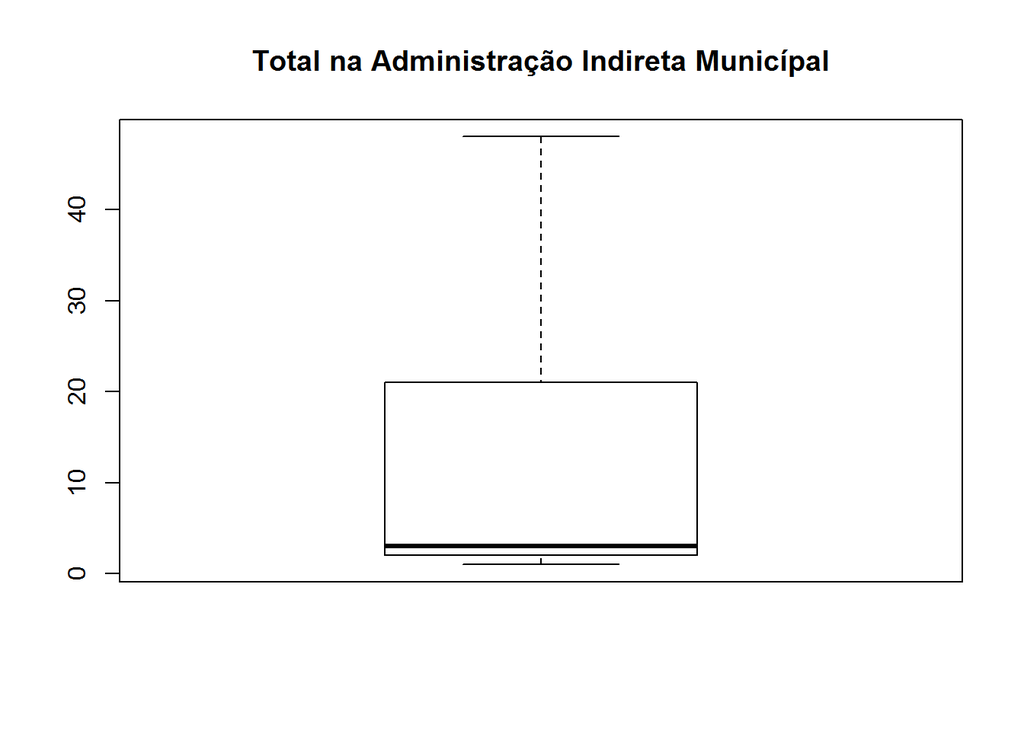

```
## [1] 69
```

```
## [1] 28.05
```

Há funcionários na administração indireta em 69 (28,05%) municipios.

## Transporte

## Qual é o quadro percentual dos serviços de transporte de passageiros existente no municípios?

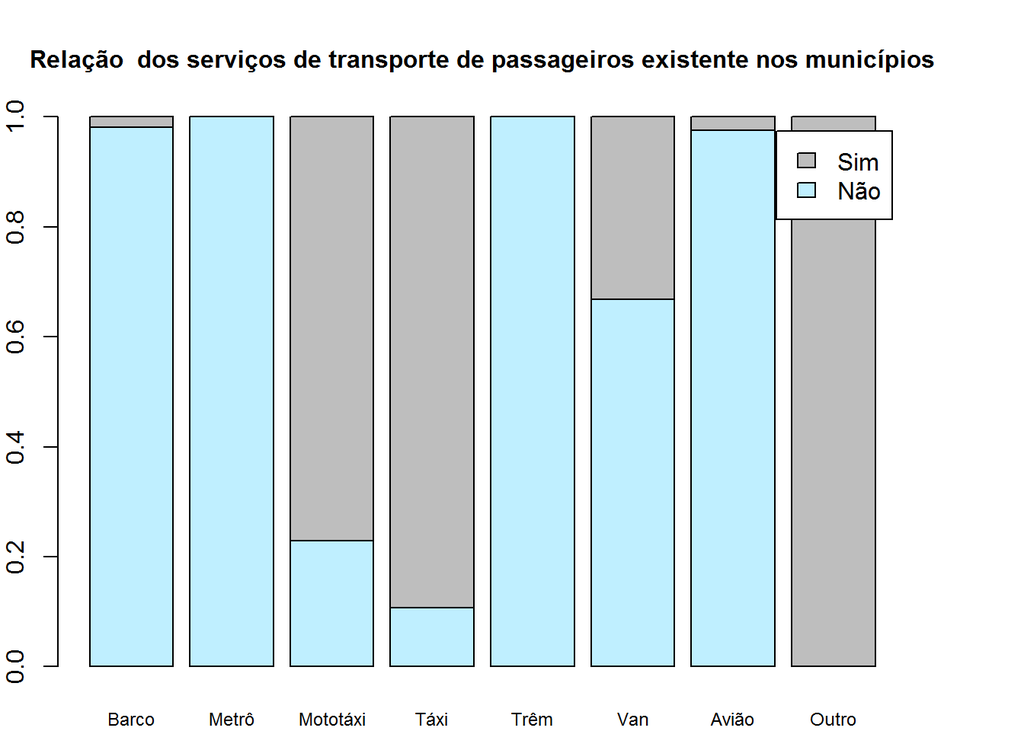

Pobulação conta basicamente com táxis.

Chama atenção a ausência de ônibus como opção de resposta

## Agropecuária

## A prefeitura desenvolve programa ou ação de estímulo à agricultura familiar?

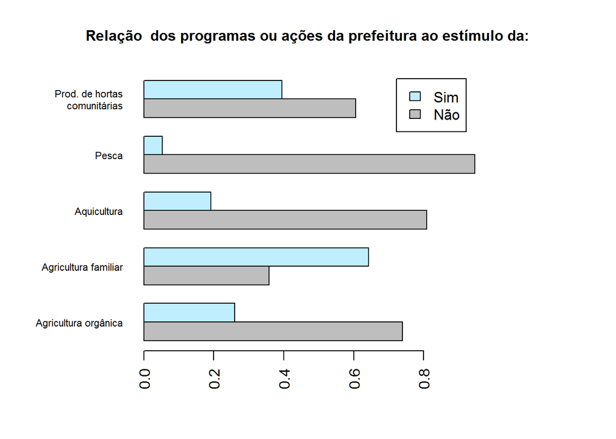

Sim, em pouco mais de 60% dos municípios.

## Qual o percentual da existência de servidor em quadro efetivo, com a responsabilidade de levantar e arquivar informações estatísticas sobre a agropecuária municipal?

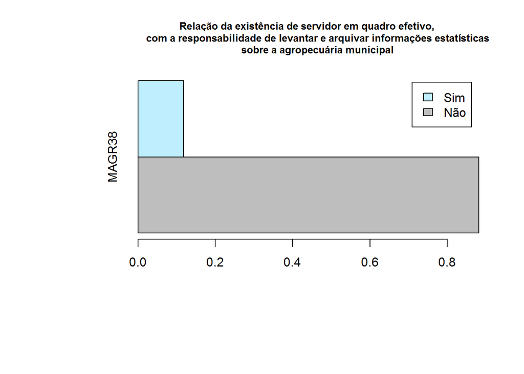

Existem em cerca de 10% de servidores em quadro efetivo, com a responsabilidade de levantar e arquivar informações estatísticas sobre a agropecuária municipal.

## A prefeitura efetivamente faz o levantamento de estatísticas sobre a agropecuária municipal?

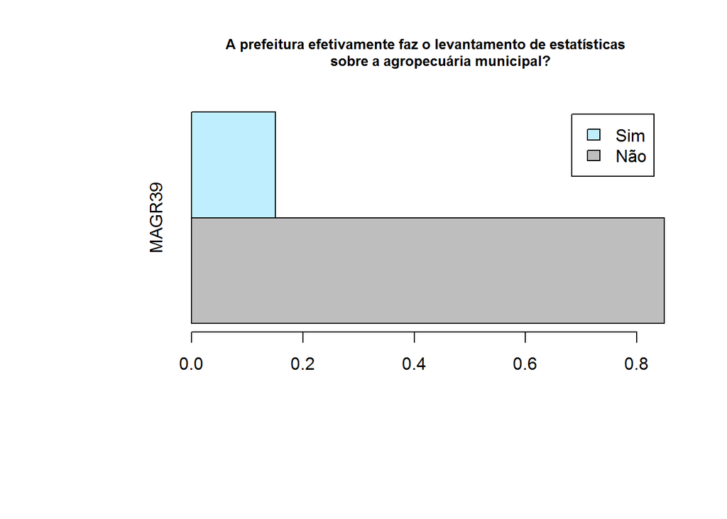

Só em menos de 20% dos municípios.

## Qual o percentual de titulares do órgão gestor da política agropecuária do sexo feminino?

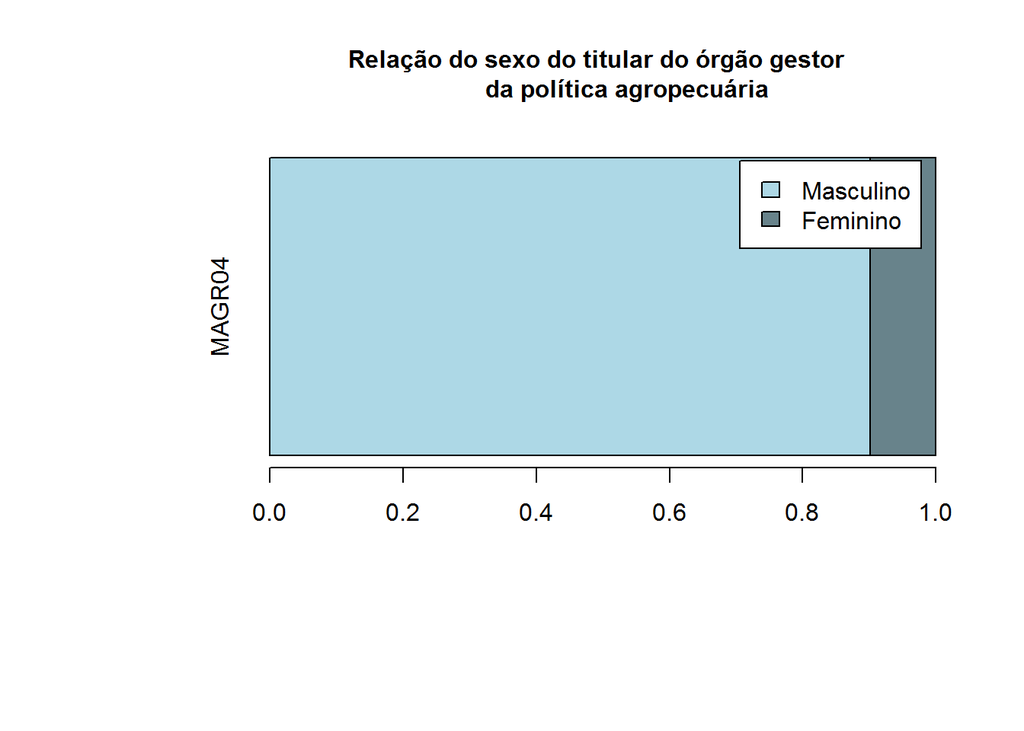

Cerca de 10% são mulheres.